# InstaCart Predictive Analysis: Logit Using `data_final`

April Leclair, Daniel Ochoa, Hoang Anh Thai Vu, Qiuhan Sun

December 11, 2017

# Prepare the Data

## Load the Data

```r
load("../Source/data_final.Rda")
```

```r
data_final <- data_final %>%
  mutate(user_id = as.numeric(user_id),
         product_id = as.numeric(product_id))
```

## Divide Train & Test Data

```r
samplesize <- floor(0.70 * nrow(data_final))
set.seed(098)
all_indices = c(1:nrow(data_final))
train_indices = sample(seq_len(nrow(data_final)), size = samplesize)
test_indices = setdiff(all_indices, train_indices)
all( ! test_indices %in% train_indices)
```

```
## [1] TRUE
```

```r
# Train_data
train = data_final[train_indices, ]
train <- train %>% arrange(user_id, product_id)

# Test_data
test = data_final[test_indices, ]
test <- test %>% arrange(user_id, product_id)

rm(samplesize, all_indices, train_indices, test_indices, data_final)
```

## Expand Memory Storage

```r
memory.limit()
```

```
## [1] 8097
```

```r
memory.limit(size=60000)
```

```
## [1] 60000
```

# Predictive Analysis: Logistic Regression

## Full Model

Fit the model for binomial regression.

```r
modelf <- glm(reordered ~ . - `user_id` - `product_id`, family = binomial(link = 'logit'), data = train)
```

Obtain the results of our model:

```r
summary(modelf)
```

```
##
## Call:
## glm(formula = reordered ~ . - user_id - product_id, family = binomial(link = "logit"),
##     data = train)
##
## Deviance Residuals:
##     Min       1Q   Median       3Q      Max
## -4.4594  -0.4303  -0.2870  -0.1536   4.8079
##
## Coefficients:
##                                           Estimate Std. Error  z value
## (Intercept)                             -4.874e+00  5.834e-02  -83.557
## user_product.orders                      1.941e-02  8.748e-04   22.188
## user_product.order_streak                1.559e-01  3.226e-03   48.331
## uid.numProducts                         -1.419e-04  9.934e-05   -1.429
## uid.reorderProducts                     -3.982e-05  1.107e-04   -0.360
## uid.reordOrdRatio                        1.450e+00  2.921e-02   49.650
## uid.aveDaysSince                         3.640e-02  3.133e-03   11.620
## uid.maxDaysSince                        -6.533e-04  8.460e-04   -0.772
## uid.sdDaysSince                         -2.447e-02  2.311e-03  -10.586
## uid.accDaysSince                         2.490e-05  3.597e-06    6.924
## uid.aveHr                                2.849e-03  1.563e-03    1.823
## uid.sdHr                                 5.176e-03  2.334e-03    2.218
## uid.aveDow                              -5.785e-04  3.446e-03   -0.168
## uid.sdDow                                1.510e-02  6.271e-03    2.408
## uid.produce_distr                       -2.813e-03  3.430e-04   -8.203
## uid.dairy_eggs_distr                    -3.582e-03  4.646e-04   -7.710
## uid.snacks_distr                        -1.490e-03  5.021e-04   -2.967
## uid.beverages_distr                     -3.914e-03  5.184e-04   -7.550
## uid.frozen_distr                        -8.519e-04  5.737e-04   -1.485
## uid.pantry_distr                         5.920e-06  8.689e-04    0.007
## uid.bakery_distr                        -2.435e-03  9.976e-04   -2.441
## uid.deli_distr                          -3.286e-03  9.493e-04   -3.462
## product.orders                           2.021e-06  2.212e-07    9.134
## product.userReordProb                    1.050e+00  6.954e-02   15.093
## product.aveTimesOrdered                 -8.570e-02  6.587e-03  -13.009
## product.reordOrdRatio                    1.882e+00  6.776e-02   27.778
## user_product.ordersSinceLastOrdered     -9.027e-02  8.011e-04 -112.670
## user_product.aveDaysSinceDifference     -5.792e-03  5.092e-04  -11.376
## product.aveDaysSinceDifference          -3.039e-02  2.970e-03  -10.233
```

[output cut: 29 more lines]

```
## user_product.ordersSinceLastOrdered      < 2e-16 ***
## user_product.aveDaysSinceDifference      < 2e-16 ***
## product.aveDaysSinceDifference           < 2e-16 ***
## user_product.orderRate                   < 2e-16 ***
## user_product.orderRateSinceFirstOrdered  < 2e-16 ***
## ---
## Signif. codes:  0 '***' 0.001 '**' 0.01 '*' 0.05 '.' 0.1 ' ' 1
##
## (Dispersion parameter for binomial family taken to be 1)
##
##     Null deviance: 968690  on 1557093  degrees of freedom
## Residual deviance: 755695  on 1557063  degrees of freedom
## AIC: 755757
##
## Number of Fisher Scoring iterations: 7
```

## Fewer Variables

`uid.reorderProducts`, `uid.maxDaysSince`, `uid.aveDow`, `uid.sdDow`, `uid.pantry_distr` & `uid.bakery_distr`

```r
model2 <- glm(reordered ~ . - `user_id` - `product_id` - `uid.reorderProducts` - `uid.maxDaysSince` - `uid.aveDow` - `uid.sdDow` - `uid.pantry_distr` - `uid.bakery_distr`, family = binomial(link = 'logit'), data = train)
```

Obtain the results of our model:

```r
summary(model2)
```

```
##
## Call:
## glm(formula = reordered ~ . - user_id - product_id - uid.reorderProducts -
##     uid.maxDaysSince - uid.aveDow - uid.sdDow - uid.pantry_distr -
##     uid.bakery_distr, family = binomial(link = "logit"), data = train)
##
## Deviance Residuals:
##     Min       1Q   Median       3Q      Max
## -4.4659  -0.4303  -0.2870  -0.1536   4.8080
##
## Coefficients:
##                                           Estimate Std. Error  z value
## (Intercept)                             -4.873e+00  5.090e-02  -95.736
## user_product.orders                      1.942e-02  8.539e-04   22.744
## user_product.order_streak                1.560e-01  3.216e-03   48.523
## uid.numProducts                         -1.761e-04  2.709e-05   -6.503
## uid.reordOrdRatio                        1.439e+00  2.441e-02   58.927
## uid.aveDaysSince                         3.621e-02  3.116e-03   11.622
## uid.sdDaysSince                         -2.572e-02  1.749e-03  -14.705
## uid.accDaysSince                         2.549e-05  3.154e-06    8.083
## uid.aveHr                                3.141e-03  1.559e-03    2.014
## uid.sdHr                                 5.944e-03  2.305e-03    2.579
## uid.produce_distr                       -2.551e-03  2.994e-04   -8.521
## uid.dairy_eggs_distr                    -3.494e-03  4.409e-04   -7.925
## uid.snacks_distr                        -1.385e-03  4.707e-04   -2.943
## uid.beverages_distr                     -3.691e-03  4.816e-04   -7.664
## uid.frozen_distr                        -5.695e-04  5.452e-04   -1.045
## uid.deli_distr                          -3.293e-03  9.403e-04   -3.502
## product.orders                           2.033e-06  2.212e-07    9.190
## product.userReordProb                    1.050e+00  6.953e-02   15.104
## product.aveTimesOrdered                 -8.592e-02  6.586e-03  -13.046
## product.reordOrdRatio                    1.881e+00  6.774e-02   27.761
## user_product.ordersSinceLastOrdered     -9.027e-02  7.999e-04 -112.859
## user_product.aveDaysSinceDifference     -5.794e-03  5.091e-04  -11.381
## product.aveDaysSinceDifference          -3.037e-02  2.969e-03  -10.227
## user_product.orderRate                   2.298e+00  2.225e-02  103.268
## user_product.orderRateSinceFirstOrdered  7.002e-01  1.458e-02   48.043
##                                         Pr(>|z|)
## (Intercept)                              < 2e-16 ***
## user_product.orders                      < 2e-16 ***
```

[output cut: 18 more lines]

```
## user_product.ordersSinceLastOrdered      < 2e-16 ***
## user_product.aveDaysSinceDifference      < 2e-16 ***
## product.aveDaysSinceDifference           < 2e-16 ***
## user_product.orderRate                   < 2e-16 ***
## user_product.orderRateSinceFirstOrdered  < 2e-16 ***
## ---
## Signif. codes:  0 '***' 0.001 '**' 0.01 '*' 0.05 '.' 0.1 ' ' 1
##
## (Dispersion parameter for binomial family taken to be 1)
##
##     Null deviance: 968690  on 1557093  degrees of freedom
## Residual deviance: 755707  on 1557069  degrees of freedom
## AIC: 755757
##
## Number of Fisher Scoring iterations: 7
```

## Even Fewer Variables

`uid.snacks_distr` & `uid.frozen_distr`

```r
model3 <- glm(reordered ~ . - `user_id` - `product_id` - `uid.reorderProducts` - `uid.maxDaysSince` - `uid.aveDow` - `uid.sdDow` - `uid.pantry_distr` - `uid.bakery_distr` - `uid.snacks_distr` - `uid.frozen_distr`, family = binomial(link = 'logit'), data = train)
```

Obtain the results of our model:

```r
summary(model3)
```

```
##
## Call:
## glm(formula = reordered ~ . - user_id - product_id - uid.reorderProducts -
##     uid.maxDaysSince - uid.aveDow - uid.sdDow - uid.pantry_distr -
##     uid.bakery_distr - uid.snacks_distr - uid.frozen_distr, family = binomial(link = "logit"),
##     data = train)
##
## Deviance Residuals:
##     Min       1Q   Median       3Q      Max
## -4.4678  -0.4303  -0.2870  -0.1536   4.8074
##
## Coefficients:
##                                           Estimate Std. Error  z value
## (Intercept)                             -4.911e+00  4.911e-02 -100.003
## user_product.orders                      1.945e-02  8.537e-04   22.781
## user_product.order_streak                1.561e-01  3.216e-03   48.541
## uid.numProducts                         -1.756e-04  2.708e-05   -6.482
## uid.reordOrdRatio                        1.425e+00  2.397e-02   59.458
## uid.aveDaysSince                         3.663e-02  3.109e-03   11.784
## uid.sdDaysSince                         -2.570e-02  1.749e-03  -14.696
## uid.accDaysSince                         2.574e-05  3.152e-06    8.165
## uid.aveHr                                3.315e-03  1.555e-03    2.132
## uid.sdHr                                 6.272e-03  2.300e-03    2.727
## uid.produce_distr                       -2.086e-03  2.380e-04   -8.762
## uid.dairy_eggs_distr                    -3.033e-03  4.024e-04   -7.538
## uid.beverages_distr                     -3.430e-03  4.610e-04   -7.440
## uid.deli_distr                          -3.065e-03  9.368e-04   -3.272
## product.orders                           2.042e-06  2.211e-07    9.238
## product.userReordProb                    1.054e+00  6.951e-02   15.168
## product.aveTimesOrdered                 -8.590e-02  6.584e-03  -13.045
## product.reordOrdRatio                    1.872e+00  6.764e-02   27.676
## user_product.ordersSinceLastOrdered     -9.028e-02  7.999e-04 -112.870
## user_product.aveDaysSinceDifference     -5.793e-03  5.091e-04  -11.380
## product.aveDaysSinceDifference          -3.090e-02  2.961e-03  -10.434
## user_product.orderRate                   2.298e+00  2.225e-02  103.282
## user_product.orderRateSinceFirstOrdered  6.996e-01  1.457e-02   48.004
##                                         Pr(>|z|)
## (Intercept)                              < 2e-16 ***
## user_product.orders                      < 2e-16 ***
## user_product.order_streak                < 2e-16 ***
```

[output cut: 15 more lines]

```
## user_product.ordersSinceLastOrdered      < 2e-16 ***
## user_product.aveDaysSinceDifference      < 2e-16 ***
## product.aveDaysSinceDifference           < 2e-16 ***
## user_product.orderRate                   < 2e-16 ***
## user_product.orderRateSinceFirstOrdered  < 2e-16 ***
## ---
## Signif. codes:  0 '***' 0.001 '**' 0.01 '*' 0.05 '.' 0.1 ' ' 1
##
## (Dispersion parameter for binomial family taken to be 1)
##
##     Null deviance: 968690  on 1557093  degrees of freedom
## Residual deviance: 755716  on 1557071  degrees of freedom
## AIC: 755762
##
## Number of Fisher Scoring iterations: 7
```

## Compare Models

```r
anova(modelf, model2, test="Chisq")
```

```
## Analysis of Deviance Table
##
## Model 1: reordered ~ (user_id + product_id + user_product.orders + user_product.order_streak +
##     uid.numProducts + uid.reorderProducts + uid.reordOrdRatio +
##     uid.aveDaysSince + uid.maxDaysSince + uid.sdDaysSince + uid.accDaysSince +
##     uid.aveHr + uid.sdHr + uid.aveDow + uid.sdDow + uid.produce_distr +
##     uid.dairy_eggs_distr + uid.snacks_distr + uid.beverages_distr +
##     uid.frozen_distr + uid.pantry_distr + uid.bakery_distr +
##     uid.deli_distr + product.orders + product.userReordProb +
##     product.aveTimesOrdered + product.reordOrdRatio + user_product.ordersSinceLastOrdered +
##     user_product.aveDaysSinceDifference + product.aveDaysSinceDifference +
##     user_product.orderRate + user_product.orderRateSinceFirstOrdered) -
##     user_id - product_id
## Model 2: reordered ~ (user_id + product_id + user_product.orders + user_product.order_streak +
##     uid.numProducts + uid.reorderProducts + uid.reordOrdRatio +
##     uid.aveDaysSince + uid.maxDaysSince + uid.sdDaysSince + uid.accDaysSince +
##     uid.aveHr + uid.sdHr + uid.aveDow + uid.sdDow + uid.produce_distr +
##     uid.dairy_eggs_distr + uid.snacks_distr + uid.beverages_distr +
##     uid.frozen_distr + uid.pantry_distr + uid.bakery_distr +
##     uid.deli_distr + product.orders + product.userReordProb +
##     product.aveTimesOrdered + product.reordOrdRatio + user_product.ordersSinceLastOrdered +
##     user_product.aveDaysSinceDifference + product.aveDaysSinceDifference +
##     user_product.orderRate + user_product.orderRateSinceFirstOrdered) -
##     user_id - product_id - uid.reorderProducts - uid.maxDaysSince -
##     uid.aveDow - uid.sdDow - uid.pantry_distr - uid.bakery_distr
##   Resid. Df Resid. Dev Df Deviance Pr(>Chi)
## 1   1557063     755695
## 2   1557069     755707 -6  -12.382  0.05398 .
## ---
## Signif. codes:  0 '***' 0.001 '**' 0.01 '*' 0.05 '.' 0.1 ' ' 1
```

```r
anova(modelf, model3, test="Chisq")
```

```
## Analysis of Deviance Table
##
## Model 1: reordered ~ (user_id + product_id + user_product.orders + user_product.order_streak +
##     uid.numProducts + uid.reorderProducts + uid.reordOrdRatio +
##     uid.aveDaysSince + uid.maxDaysSince + uid.sdDaysSince + uid.accDaysSince +
##     uid.aveHr + uid.sdHr + uid.aveDow + uid.sdDow + uid.produce_distr +
##     uid.dairy_eggs_distr + uid.snacks_distr + uid.beverages_distr +
##     uid.frozen_distr + uid.pantry_distr + uid.bakery_distr +
##     uid.deli_distr + product.orders + product.userReordProb +
##     product.aveTimesOrdered + product.reordOrdRatio + user_product.ordersSinceLastOrdered +
##     user_product.aveDaysSinceDifference + product.aveDaysSinceDifference +
##     user_product.orderRate + user_product.orderRateSinceFirstOrdered) -
##     user_id - product_id
## Model 2: reordered ~ (user_id + product_id + user_product.orders + user_product.order_streak +
##     uid.numProducts + uid.reorderProducts + uid.reordOrdRatio +
##     uid.aveDaysSince + uid.maxDaysSince + uid.sdDaysSince + uid.accDaysSince +
##     uid.aveHr + uid.sdHr + uid.aveDow + uid.sdDow + uid.produce_distr +
##     uid.dairy_eggs_distr + uid.snacks_distr + uid.beverages_distr +
##     uid.frozen_distr + uid.pantry_distr + uid.bakery_distr +
##     uid.deli_distr + product.orders + product.userReordProb +
##     product.aveTimesOrdered + product.reordOrdRatio + user_product.ordersSinceLastOrdered +
##     user_product.aveDaysSinceDifference + product.aveDaysSinceDifference +
##     user_product.orderRate + user_product.orderRateSinceFirstOrdered) -
##     user_id - product_id - uid.reorderProducts - uid.maxDaysSince -
##     uid.aveDow - uid.sdDow - uid.pantry_distr - uid.bakery_distr -
##     uid.snacks_distr - uid.frozen_distr
##   Resid. Df Resid. Dev Df Deviance Pr(>Chi)
## 1   1557063     755695
## 2   1557071     755716 -8  -21.162 0.006729 **
## ---
## Signif. codes:  0 '***' 0.001 '**' 0.01 '*' 0.05 '.' 0.1 ' ' 1
```

```r
anova(model2, model3, test="Chisq")
```

```
## Analysis of Deviance Table
##
## Model 1: reordered ~ (user_id + product_id + user_product.orders + user_product.order_streak +
##     uid.numProducts + uid.reorderProducts + uid.reordOrdRatio +
##     uid.aveDaysSince + uid.maxDaysSince + uid.sdDaysSince + uid.accDaysSince +
##     uid.aveHr + uid.sdHr + uid.aveDow + uid.sdDow + uid.produce_distr +
##     uid.dairy_eggs_distr + uid.snacks_distr + uid.beverages_distr +
##     uid.frozen_distr + uid.pantry_distr + uid.bakery_distr +
##     uid.deli_distr + product.orders + product.userReordProb +
##     product.aveTimesOrdered + product.reordOrdRatio + user_product.ordersSinceLastOrdered +
##     user_product.aveDaysSinceDifference + product.aveDaysSinceDifference +
##     user_product.orderRate + user_product.orderRateSinceFirstOrdered) -
##     user_id - product_id - uid.reorderProducts - uid.maxDaysSince -
##     uid.aveDow - uid.sdDow - uid.pantry_distr - uid.bakery_distr
## Model 2: reordered ~ (user_id + product_id + user_product.orders + user_product.order_streak +
##     uid.numProducts + uid.reorderProducts + uid.reordOrdRatio +
##     uid.aveDaysSince + uid.maxDaysSince + uid.sdDaysSince + uid.accDaysSince +
##     uid.aveHr + uid.sdHr + uid.aveDow + uid.sdDow + uid.produce_distr +
##     uid.dairy_eggs_distr + uid.snacks_distr + uid.beverages_distr +
##     uid.frozen_distr + uid.pantry_distr + uid.bakery_distr +
##     uid.deli_distr + product.orders + product.userReordProb +
##     product.aveTimesOrdered + product.reordOrdRatio + user_product.ordersSinceLastOrdered +
##     user_product.aveDaysSinceDifference + product.aveDaysSinceDifference +
##     user_product.orderRate + user_product.orderRateSinceFirstOrdered) -
##     user_id - product_id - uid.reorderProducts - uid.maxDaysSince -
##     uid.aveDow - uid.sdDow - uid.pantry_distr - uid.bakery_distr -
##     uid.snacks_distr - uid.frozen_distr
##   Resid. Df Resid. Dev Df Deviance Pr(>Chi)
## 1   1557069     755707
## 2   1557071     755716 -2  -8.7808   0.0124 *
## ---
## Signif. codes:  0 '***' 0.001 '**' 0.01 '*' 0.05 '.' 0.1 ' ' 1
```

## Testing Function

```r
accuracy_test <- function(pred_mod) {

  # confusion matrix, precision, recall
  cmt <- confusionMatrix(pred_mod, test$reordered)
  recall <- cmt[2,2]/sum(cmt[2,])
  precision <- cmt[2,2]/sum(cmt[,2])
  specificity <- cmt[1,1]/sum(cmt[1,])
  accuracy <- (cmt[2,2]+cmt[1,1])/(cmt[1,1]+cmt[2,2]+cmt[2,1]+cmt[1,2])

  # print output
  result=list(confMatrTable = unlist(cmt), precision=precision, recall=recall,
              specificity=specificity, accuracy=accuracy)

  return(result)
}



f1_test <- function (pred, ref,user_id) {
  require(ModelMetrics)
  dt <- tibble(user_id, pred, ref)
  dt <- dt %>%
    group_by(user_id)%>%
    mutate(f1_score = f1Score(pred,ref))%>%
    summarise(f1_score = mean(f1_score,na.rm=TRUE))
  f1_mean <- mean(dt$f1_score,na.rm=TRUE)
  return (f1_mean)
}



f1_comp_test <- function(model, cutoff){

  # prediction for our model
  pred_mod_tem <- predict(model, newdata = test, type = 'response')
  pred_mod <- ifelse(pred_mod_tem > cutoff, 1, 0)
  pred_f1 <- f1_test(pred_mod, test$reordered, test$user_id)

  # prediction for null model
  pred_null <- ifelse(test$user_product.order_streak > 0, 1, 0)
  null_f1 <- f1_test(pred_null, test$reordered, test$user_id)

  # comparison to null model
  diff_raw <- pred_f1-null_f1
  diff_perc <- diff_raw/null_f1


  acc_output <- accuracy_test(pred_mod)

  # print output
  result1=list(pred_f1=pred_f1)
  result2=list(null_f1=null_f1)
  result3=list(diff_raw=diff_raw, diff_perc=diff_perc)
  result4=acc_output

  return(c(result1, result2, result3, result4))
}
```

## Results

```r
f1_comp_test(model3, 0.43)
```

```
## $pred_f1
## [1] 0.3913346
##
## $null_f1
## [1] 0.2922953
##
## $diff_raw
## [1] 0.09903926
##
## $diff_perc
## [1] 0.3388328
##
## $confMatrTable
##        [,1]  [,2]
## [1,] 596187  8878
## [2,]  49927 12334
##
## $precision
## [1] 0.5814633
##
## $recall
## [1] 0.1981015
##
## $specificity
## [1] 0.9853272
##
## $accuracy
## [1] 0.9118797
```

## Plot GLM

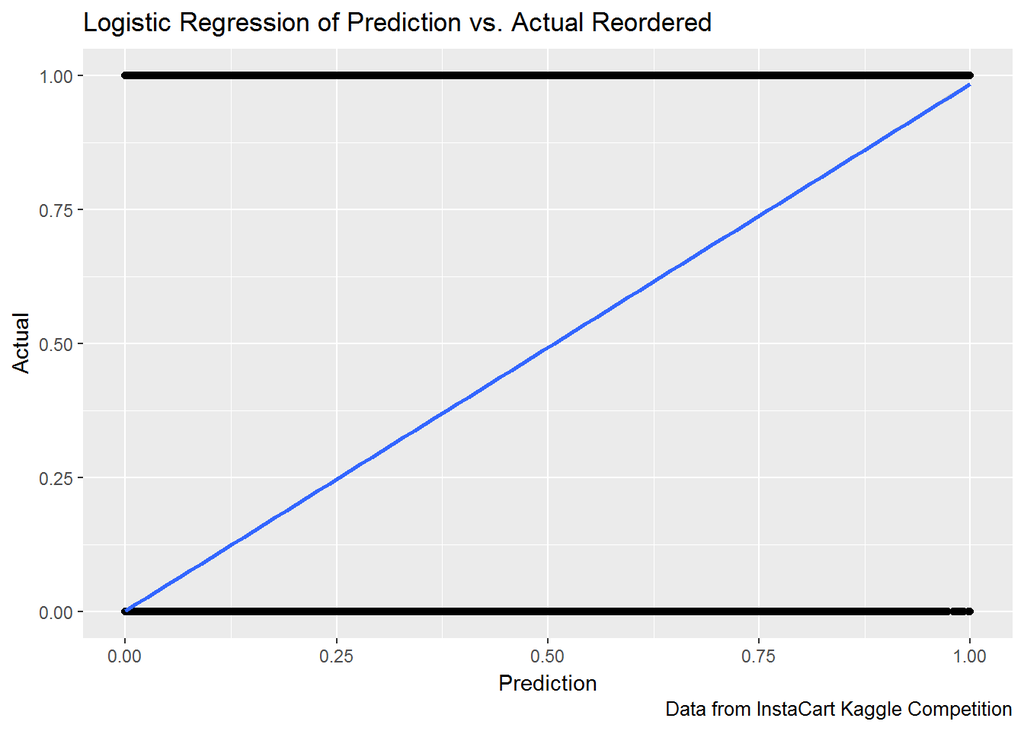

```r
pred_logit_pre <- predict(model3, newdata = test, type = 'response')

ggplot(test, aes(x=pred_logit_pre, y=reordered)) + geom_point() +
  stat_smooth(method="glm", family="binomial", se=TRUE) +
  labs(x="Prediction", y="Actual",
       title="Logistic Regression of Prediction vs. Actual Reordered",
       caption="Data from InstaCart Kaggle Competition")
```

## ROC

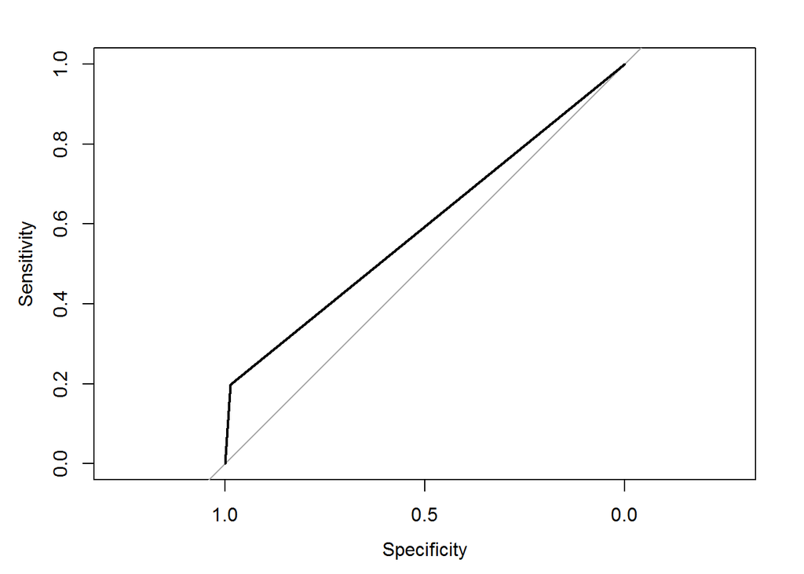

```
##
## Call:
## roc.default(response = test$reordered, predictor = pred_logit,     plot = TRUE)
##
## Data: pred_logit in 605065 controls (test$reordered 0) < 62261 cases (test$reordered 1).
## Area under the curve: 0.5917
```

```r
pred_logit <- ifelse(pred_logit_pre > 0.43, 1, 0)
roc(test$reordered, pred_logit, plot=TRUE)
```

## Below codes are included for exploration (for fun)

## Comparison between Linear and Logistic Model - included for coolness in features

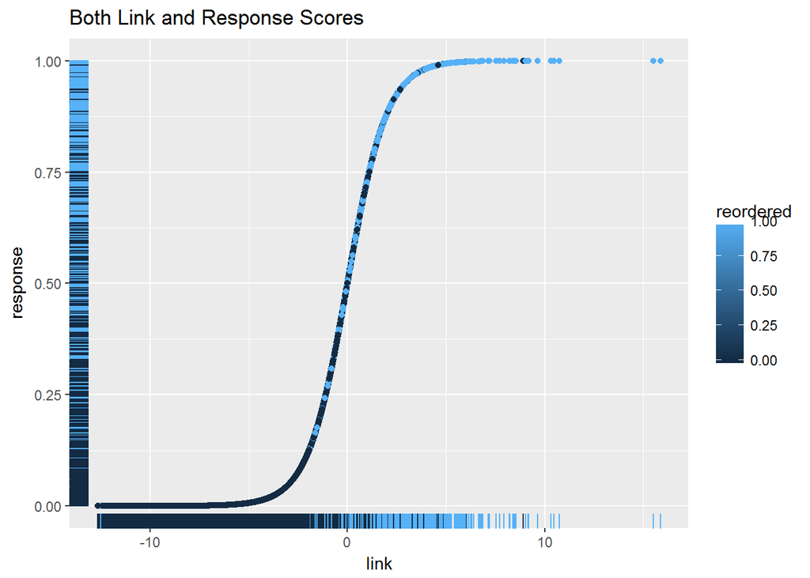

```r
pred_logit_linkscores <- predict(model3, newdata = test, type = 'link')
pred_logit_respscores <- predict(model3, newdata = test, type = 'response')

score_data <- data.frame(link=pred_logit_linkscores,
                         response=pred_logit_respscores,
                         reordered=test$reordered,
                         stringsAsFactors=FALSE)

score_data %>%
  ggplot(aes(x=link, y=response, col=reordered)) +
  # scale_color_manual(values=c("black", "red")) +
  geom_point() +
  geom_rug() +
  ggtitle("Both Link and Response Scores")
```

```r
summary_model3 <- summary(model3)
list( summary_model3$coefficient,
      round( 1 - ( summary_model3$deviance / summary_model3$null.deviance ), 2 ) )
```

```
## [[1]]
##                                              Estimate   Std. Error
## (Intercept)                             -4.910778e+00 4.910631e-02
## user_product.orders                      1.944891e-02 8.537271e-04
## user_product.order_streak                1.560969e-01 3.215799e-03
## uid.numProducts                         -1.755624e-04 2.708481e-05
## uid.reordOrdRatio                        1.425147e+00 2.396880e-02
## uid.aveDaysSince                         3.663312e-02 3.108598e-03
## uid.sdDaysSince                         -2.569781e-02 1.748598e-03
## uid.accDaysSince                         2.574060e-05 3.152516e-06
## uid.aveHr                                3.315460e-03 1.555181e-03
## uid.sdHr                                 6.271966e-03 2.299542e-03
## uid.produce_distr                       -2.085657e-03 2.380366e-04
## uid.dairy_eggs_distr                    -3.033207e-03 4.023681e-04
## uid.beverages_distr                     -3.429801e-03 4.610225e-04
## uid.deli_distr                          -3.064589e-03 9.367533e-04
## product.orders                           2.042480e-06 2.210981e-07
## product.userReordProb                    1.054243e+00 6.950629e-02
## product.aveTimesOrdered                 -8.589502e-02 6.584461e-03
## product.reordOrdRatio                    1.871936e+00 6.763729e-02
## user_product.ordersSinceLastOrdered     -9.028220e-02 7.998761e-04
## user_product.aveDaysSinceDifference     -5.793139e-03 5.090661e-04
## product.aveDaysSinceDifference          -3.089712e-02 2.961131e-03
## user_product.orderRate                   2.297509e+00 2.224503e-02
## user_product.orderRateSinceFirstOrdered  6.995642e-01 1.457306e-02
##                                             z value      Pr(>|z|)
## (Intercept)                             -100.002979  0.000000e+00
## user_product.orders                       22.781181 7.046491e-115
## user_product.order_streak                 48.540613  0.000000e+00
## uid.numProducts                           -6.481950  9.054448e-11
## uid.reordOrdRatio                         59.458447  0.000000e+00
## uid.aveDaysSince                          11.784453  4.694597e-32
## uid.sdDaysSince                          -14.696233  6.814655e-49
## uid.accDaysSince                           8.165096  3.211792e-16
## uid.aveHr                                  2.131881  3.301665e-02
## uid.sdHr                                   2.727485  6.381911e-03
## uid.produce_distr                         -8.761918  1.919560e-18
## uid.dairy_eggs_distr                      -7.538390  4.758095e-14
## uid.beverages_distr                       -7.439552  1.010273e-13
## uid.deli_distr                            -3.271501  1.069781e-03
## product.orders                             9.237893  2.513980e-20
## product.userReordProb                     15.167595  5.796192e-52
## product.aveTimesOrdered                  -13.045109  6.775991e-39
## product.reordOrdRatio                     27.676095 1.354599e-168
## user_product.ordersSinceLastOrdered     -112.870235  0.000000e+00
## user_product.aveDaysSinceDifference      -11.379935  5.263887e-30
## product.aveDaysSinceDifference           -10.434232  1.730078e-25
## user_product.orderRate                   103.281889  0.000000e+00
## user_product.orderRateSinceFirstOrdered   48.003918  0.000000e+00
##
## [[2]]
## [1] 0.22
```

A fast check on all the p-values of the model indicates significance, meaning that our model is a legitimate one. A pseudo R square of 0.22 tells that only 22 percent of the variance is explained. In other words, it is telling us that the model isn’t powerful enough to predict reorder binary outcomes with high reliability. Since this is more of a dataset problem ( suggests collecting other variables to include to the dataset ) and there’s not much we can do about it at this stage, so we’ll simply move on to the next part where we’ll start looking at the predictions made by the model.

Given that our model’s final objective is to classify new instances into one of two categories, we will want the model to give high scores to positive instances ( 1: reordered ) and low scores ( 0 : not reordered ) otherwise. Thus for a ideal double density plot you want the distribution of scores to be separated, with the score of the negative instances to be on the left and the score of the positive instance to be on the right.

In the current case, both distributions are very skewed to the left and are on top of each other. Not only is the predicted probability for the negative outcomes low, but the probability for the positive outcomes are also way lower than it should be. The reason for this is because our dataset only consists of only a few positive instances ( reordered ). Thus our predicted scores sort of gets pulled towards a lower number because of the majority of the data being negative instances.

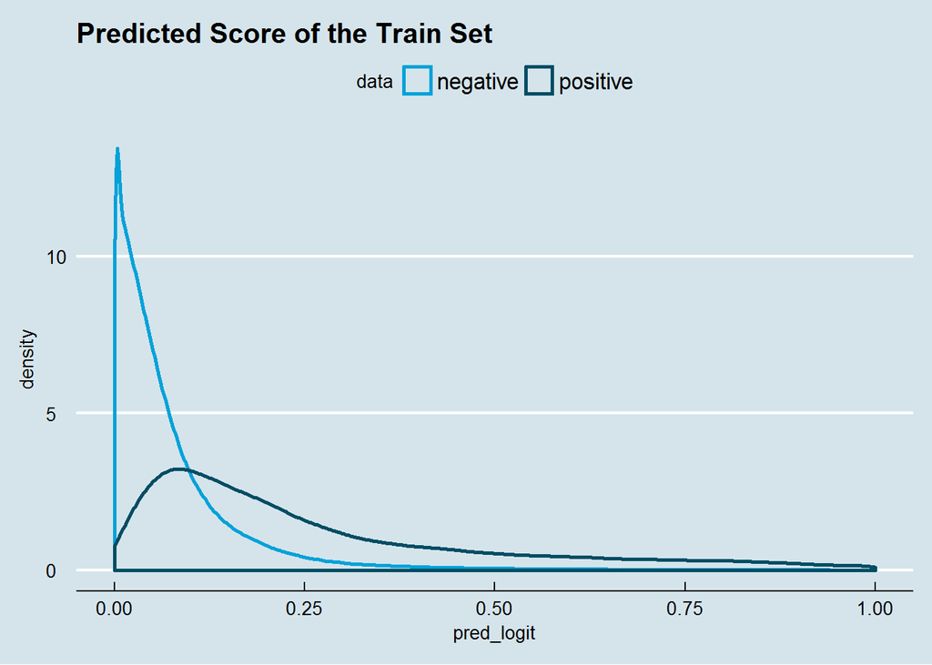

```r
# prediction
train$pred_logit <- predict( model3, newdata = train, type = "response" )
test$pred_logit  <- predict( model3, newdata = test , type = "response" )

# distribution of the prediction score grouped by known outcome
ggplot( train, aes( pred_logit, color = as.factor(reordered) ) ) +
geom_density( size = 1 ) +
ggtitle( "Predicted Score of the Train Set" ) +
scale_color_economist( name = "data", labels = c( "negative", "positive" ) ) +
theme_economist()
```